# Lab 5: Spam Detection

In this assignment, we will build a recurrent neural network to classify a SMS text message as "spam" or "not spam". In the process, you will

1. Clean and process text data for machine learning.
2. Understand and implement a character-level recurrent neural network.
3. Understand batching for a recurrent neural network, and develop custom Dataset and DataLoaders with collate_fn to implement RNN batching.

### What to submit

Submit a PDF file containing all your code, outputs, and write-up. You can produce a PDF of your Google Colab file by going to File > Print and then save as PDF. The Colab instructions have more information.

Do not submit any other files produced by your code.

Include a link to your colab file in your submission.

## Colab Link

https://colab.research.google.com/github/sissi820li/Deep-Learning-Project/blob/main/Lab%205/Lab%205%20Spam%20Detection.ipynb

Include a link to your Colab file here. If you would like the TA to look at your Colab file in case your solutions are cut off, **please make sure that your Colab file is publicly accessible at the time of submission**.

```python
import torch
import torch.nn as nn
import torch.nn.functional as F
import torch.optim as optim
import numpy as np
import time
from torch.nn.utils.rnn import pad_sequence
from torch.utils.data import DataLoader, Dataset
from sklearn.model_selection import train_test_split
```

## Part 1. Data Cleaning [15 pt]

We will be using the "SMS Spam Collection Data Set" available at http://archive.ics.uci.edu/ml/datasets/SMS+Spam+Collection

There is a link to download the "Data Folder" at the very top of the webpage. Download the zip file, unzip it, and upload the file `SMSSpamCollection` to Colab.

### Part (a) [1 pt]

Open up the file in Python, and print out one example of a spam SMS, and one example of a non-spam SMS.

What is the label value for a spam message, and what is the label value for a non-spam message?

The label value for a spam message is "spam" and the label value for a non-spam message is "ham".

```python
for line in open('SMSSpamCollection'):
  if line[0] == "s":
    print(line)
    break

for line in open('SMSSpamCollection'):
  if line[0] == 'h':
    print(line)
    break
```

```
spam	Free entry in 2 a wkly comp to win FA Cup final tkts 21st May 2005. Text FA to 87121 to receive entry question(std txt rate)T&C's apply 08452810075over18's

ham	Go until jurong point, crazy.. Available only in bugis n great world la e buffet... Cine there got amore wat...
```

### Part (b) [1 pt]

How many spam messages are there in the data set? How many non-spam messages are there in the data set?

```python
spam = 0
ham = 0
for line in open('SMSSpamCollection'):
    if line[0] == 's':
        spam += 1
    elif line[0] == 'h':
        ham += 1

print("Number of spam messages in the data set:", spam)
print("Number of non-spam messages in the data set:", ham)
```

```
Number of spam messages in the data set: 747
Number of non-spam messages in the data set: 4827
```

### Part (c) [4 pt]

load and parse the data into two lists: sequences and labels. Create character-level stoi and itos dictionaries. Reserve the index 0 for padding. Convert the sequences to list of character ids using stoi dictionary and convert the labels to a list of 0s and 1s by assinging class "ham" to 0 and class "spam" to 1.

```python
sequences = []
labels = []

for line in open('SMSSpamCollection'):
    if line[0] == 'h':
        labels.append('ham')
        sequences.append(line[3:].strip())
    elif line[0] == 's':
        labels.append('spam')
        sequences.append(line[4:].strip())

unique_chars = set(''.join(sequences)) #join all sequences into a single string and remove duplicate characters
stoi = {'<PAD>': 0}
itos = {0: '<PAD>'}

#Map each unique character to a unique integer ID, starting from 1 (0 is reserved for padding)
for idx, char in enumerate(sorted(unique_chars), start=1):
    stoi[char] = idx
    itos[idx] = char
    #stoi[' '] = 1, stoi['a'] = 2

# Use stoi mapping to convert each char in each sequence
encoded_sequences = [[stoi[char] for char in seq] for seq in sequences]
encoded_labels = [1 if label == 'spam' else 0 for label in labels]

print(f"Total unique characters including padding: {len(stoi)}")
print(f"Original data: '{sequences[2]}'")
print(f"Converted sequence: {encoded_sequences[2]}")
print(f"Encoded label: spam -> {encoded_labels[2]}")
```

```
Total unique characters including padding: 120
Original data: 'Free entry in 2 a wkly comp to win FA Cup final tkts 21st May 2005. Text FA to 87121 to receive entry question(std txt rate)T&C's apply 08452810075over18's'
Converted sequence: [39, 82, 69, 69, 1, 69, 78, 84, 82, 89, 1, 73, 78, 1, 19, 1, 65, 1, 87, 75, 76, 89, 1, 67, 79, 77, 80, 1, 84, 79, 1, 87, 73, 78, 1, 39, 34, 1, 36, 85, 80, 1, 70, 73, 78, 65, 76, 1, 84, 75, 84, 83, 1, 19, 18, 83, 84, 1, 46, 65, 89, 1, 19, 17, 17, 22, 15, 1, 53, 69, 88, 84, 1, 39, …
Encoded label: spam -> 1
```

### Part (d) [4 pt]

Use train_test_split function from sklearn (https://scikit-learn.org/dev/modules/generated/sklearn.model_selection.train_test_split.html) to split the data indices into `train`, `valid`, and `test`. Use a 60-20-20 split.

You saw in part (b) that there are many more non-spam messages than spam messages. This **imbalance** in our training data will be problematic for training. We can fix this disparity by duplicating spam messages in the training set, so that the training set is roughly balanced.

```python
x = encoded_sequences
y = encoded_labels

indices = list(range(len(x)))

# Separate 20% for testing and 80% for training and validation
train_val_idx, test_index = train_test_split(indices, test_size=0.20, random_state=42)

# Separate 20% of original data for validation, so take 1/4th of train_val_idx for validation
train_index, val_index = train_test_split(train_val_idx, test_size=0.25, random_state=42)

# Use indices to grab data for corresponding data sets
train_x = [x[idx] for idx in train_index]
train_y = [y[idx] for idx in train_index]

val_x = [x[idx] for idx in val_index]
val_y = [y[idx] for idx in val_index]

test_x = [x[idx] for idx in test_index]
test_y = [y[idx] for idx in test_index]

train_spam = []
for idx, item in enumerate(train_x):
    if train_y[idx] == 1:
        train_spam.append(item)

# duplicate each spam message 6 more times
train_x = train_x + train_spam * 6
train_y = train_y + [1] * (len(train_spam) * 6)

datasets = {
    "Training Set": train_y,
    "Validation Set": val_y,
    "Test Set": test_y
}
```

### Part (e) [4 pt]

Since each sequence has a different length, we cannot use the default DataLoader. We need to change the DataLoader such that it can pad differnt sequence sizes within the batch. To do this, we need to introduce a **collate_fn** to the DataLoader such that it uses **pad_sequence** function (https://pytorch.org/docs/stable/generated/torch.nn.utils.rnn.pad_sequence.html) to pad the sequences within the batch to the same size.

We also need a custom Dataset class to return a pair of sequence and label for each example. Complete the code below to address these.

Hint:

- https://stanford.edu/~shervine/blog/pytorch-how-to-generate-data-parallel
- https://plainenglish.io/blog/understanding-collate-fn-in-pytorch-f9d1742647d3

```python
class MyDataset(Dataset):
    def __init__(self, sequences, labels):
        self.sequences = sequences
        self.labels = labels

    def __len__(self):
        return len(self.sequences)

    def __getitem__(self, idx):
        # Return a single (sequence, label) pair as PyTorch tensors
        seq_tensor = torch.tensor(self.sequences[idx], dtype=torch.long)
        label_tensor = torch.tensor(self.labels[idx], dtype=torch.float32)
        return seq_tensor, label_tensor

def collate_sequences(batch):
    # Unzip the batch into lists
    sequences = [item[0] for item in batch]
    labels = [item[1] for item in batch]
    padded_sequences = pad_sequence(sequences, batch_first=True, padding_value=0)
    labels_tensor = torch.stack(labels) #stack labels into a single tensor

    return padded_sequences, labels_tensor

train_loader = DataLoader(dataset=MyDataset(train_x, train_y), batch_size=32, shuffle=True, collate_fn=collate_sequences)
val_loader = DataLoader(dataset=MyDataset(val_x, val_y), batch_size=32, shuffle=False, collate_fn=collate_sequences)
test_loader = DataLoader(dataset=MyDataset(test_x, test_y), batch_size=32, shuffle=False, collate_fn=collate_sequences)
```

### Part (f) [1 pt]

Take a look at 10 batches in `train_loader`. What is the maximum length of the input sequence in each batch? How many `<pad>` tokens are used in each of the 10 batches?

```python
# For standard DataLoader with shuffle=True, the batch will randomly grabs 32 messages. If a batch contains a 5 char message and a 150 char message, the 5 char message will be padded with 145 <pad> tokens to match the length of the longest sequence in that batch. Number of <pad> tokens is added up from all sequences in a batch.
i = 0
for padded_sequences, labels in train_loader:
    if i >= 10:
        break

    pad = 0
    print("Batch", i+1, ":")
    print("\tMaximum Length =", int(padded_sequences.shape[1]))
    for seq in padded_sequences:
        pad += (seq == 0).sum().item()
    print("\tNumber of <pad> tokens =", int(pad))

    i += 1
```

```
Batch 1 :
	Maximum Length = 173
	Number of <pad> tokens = 2268
Batch 2 :
	Maximum Length = 174
	Number of <pad> tokens = 1915
Batch 3 :
	Maximum Length = 180
	Number of <pad> tokens = 2557
Batch 4 :
	Maximum Length = 183
	Number of <pad> tokens = 2628
Batch 5 :
	Maximum Length = 322
	Number of <pad> tokens = 7111
Batch 6 :
	Maximum Length = 163
	Number of <pad> tokens = 1847
Batch 7 :
	Maximum Length = 247
	Number of <pad> tokens = 4961
Batch 8 :
	Maximum Length = 224
	Number of <pad> tokens = 3929
Batch 9 :
	Maximum Length = 257
	Number of <pad> tokens = 5096
Batch 10 :
	Maximum Length = 169
	Number of <pad> tokens = 1524
```

## Part 2. Model Building [8 pt]

Build a recurrent neural network model, using an architecture of your choosing. Use the one-hot embedding of each character as input to your recurrent network. Use one or more fully-connected layers to make the prediction based on your recurrent network output.

Instead of using the RNN output value for the final token, another often used strategy is to max-pool over the entire output array. That is, instead of calling something like:

```
out, _ = self.rnn(x)
self.fc(out[:, -1, :])
```

where `self.rnn` is an `nn.RNN`, `nn.GRU`, or `nn.LSTM` module, and `self.fc` is a fully-connected layer, we use:

```
out, _ = self.rnn(x)
self.fc(torch.max(out, dim=1)[0])
```

This works reasonably in practice. An even better alternative is to concatenate the max-pooling and average-pooling of the RNN outputs:

```
out, _ = self.rnn(x)
out = torch.cat([torch.max(out, dim=1)[0],
                 torch.mean(out, dim=1)], dim=1)
self.fc(out)
```

We encourage you to try out all these options. The way you pool the RNN outputs is one of the "hyperparameters" that you can choose to tune later on.

```python
# You might find this code helpful for obtaining
# PyTorch one-hot vectors.

ident = torch.eye(10)
print(ident[0]) # one-hot vector
print(ident[1]) # one-hot vector
x = torch.tensor([[1, 2], [3, 4]])
print(ident[x]) # one-hot vectors
```

```
tensor([1., 0., 0., 0., 0., 0., 0., 0., 0., 0.])
tensor([0., 1., 0., 0., 0., 0., 0., 0., 0., 0.])
tensor([[[0., 1., 0., 0., 0., 0., 0., 0., 0., 0.],
         [0., 0., 1., 0., 0., 0., 0., 0., 0., 0.]],

        [[0., 0., 0., 1., 0., 0., 0., 0., 0., 0.],
         [0., 0., 0., 0., 1., 0., 0., 0., 0., 0.]]])
```

```python
class RNN(nn.Module):
  def __init__(self, vocab_size, hidden_size, n_layers=1):
      super(RNN, self).__init__()

      self.ident = torch.eye(vocab_size)
      self.rnn = nn.GRU(vocab_size, hidden_size, n_layers, batch_first=True)
      self.classifier = nn.Linear(hidden_size, 2)

  def forward(self, x):
      inp_x = self.ident[x]
      output, _ = self.rnn(inp_x)

      out = torch.max(output, dim=1)[0]

      out = self.classifier(out)
      return out
```

## Part 3. Training [16 pt]

### Part (a) [4 pt]

Complete the `get_accuracy` function, which will compute the accuracy (rate) of your model across a dataset (e.g. validation set).

```python
def get_accuracy(model, data_loader):
    """ Compute the accuracy of the `model` across a dataset `data`

    Example usage:

    >>> model = MyRNN() # to be defined
    >>> get_accuracy(model, valid) # the variable `valid` is from above
    """
    correct = 0
    total = 0

    with torch.no_grad():  # Turn off gradient tracking to save memory and time
        for sequences, labels in data_loader:
            output = model(sequences)
            pred = output.max(1, keepdim=True)[1] # Get pred (0 or 1)
            correct += pred.eq(labels.view_as(pred)).sum().item() # Compare predictions to labels
            total += labels.shape[0]

    return correct / total

def evaluate(model, data_loader, criterion):
    """ Evaluate the network on the validation/test set. """
    total_loss = 0.0
    total_err = 0.0
    total_epoch = 0

    with torch.no_grad():

        for sequences, labels in data_loader:
            labels = labels.long()
            outputs = model(sequences)
            loss = criterion(outputs, labels)
            pred = outputs.max(1, keepdim=True)[1]
            corr = pred.ne(labels.view_as(pred))

            total_err += int(corr.sum().item())
            total_loss += loss.item()
            total_epoch += len(labels)

    err = float(total_err) / total_epoch
    avg_loss = float(total_loss) / len(data_loader)

    return err, avg_loss
```

### Part (b) [4 pt]

Train your model. Plot the training curve of your final model. Your training curve should have the training/validation loss and accuracy plotted periodically.

Note: Not all of your batches will have the same batch size. In particular, if your training set does not divide evenly by your batch size, there will be a batch that is smaller than the rest.

```python
def get_model_name(name, batch_size, learning_rate, epoch):
    path = "model_{0}_bs{1}_lr{2}_epoch{3}".format(name,
                                                   batch_size,
                                                   learning_rate,
                                                  epoch)
    return path

def train(model, train_loader, valid_loader, num_epochs=30, learning_rate=0.001):
    criterion = nn.CrossEntropyLoss()
    optimizer = torch.optim.Adam(model.parameters(), lr=learning_rate)

    train_err, train_loss, val_err, val_loss = [], [], [], []

    for epoch in range(num_epochs):
        for sequences, labels in train_loader:
            optimizer.zero_grad()
            pred = model(sequences)
            loss = criterion(pred, labels.long())  # Ensure labels are LongTensors for Cross Entropy Loss
            loss.backward()
            optimizer.step()

        t_err, t_loss = evaluate(model, train_loader, criterion)
        v_err, v_loss = evaluate(model, valid_loader, criterion)

        train_err.append(t_err)
        train_loss.append(t_loss)
        val_err.append(v_err)
        val_loss.append(v_loss)

        print(("Epoch {}: Train err: {}, Train loss: {} | "+
                    "Validation err: {}, Validation loss: {}").format(
                        epoch + 1,
                        t_err,
                        t_loss,
                        v_err,
                        v_loss
                    ))
        model_name = getattr(model, 'name', 'rnn')
        batch_size = train_loader.batch_size
        model_path = get_model_name(model_name, batch_size, learning_rate, epoch)
        torch.save(model.state_dict(), model_path)

    np.savetxt("{}_train_err.csv".format(model_path), train_err)
    np.savetxt("{}_train_loss.csv".format(model_path), train_loss)
    np.savetxt("{}_val_err.csv".format(model_path), val_err)
    np.savetxt("{}_val_loss.csv".format(model_path), val_loss)

def plot_training_curve(path):
    import matplotlib.pyplot as plt
    train_err = np.loadtxt("{}_train_err.csv".format(path))
    val_err = np.loadtxt("{}_val_err.csv".format(path))
    train_loss = np.loadtxt("{}_train_loss.csv".format(path))
    val_loss = np.loadtxt("{}_val_loss.csv".format(path))
    plt.title("Train vs Validation Error")
    n = len(train_err) # number of epochs
    plt.plot(range(1,n+1), train_err, label="Train")
    plt.plot(range(1,n+1), val_err, label="Validation")
    plt.xlabel("Epoch")
    plt.ylabel("Error")
    plt.legend(loc='best')
    plt.show()
    plt.title("Train vs Validation Loss")
    plt.plot(range(1,n+1), train_loss, label="Train")
    plt.plot(range(1,n+1), val_loss, label="Validation")
    plt.xlabel("Epoch")
    plt.ylabel("Loss")
    plt.legend(loc='best')
    plt.show()
```

```
Epoch 1: Train err: 0.05848050649783405, Train loss: 0.21123309554334016 | Validation err: 0.042152466367713005, Validation loss: 0.15741236646260534
Epoch 2: Train err: 0.051649450183272244, Train loss: 0.14756764182226456 | Validation err: 0.030493273542600896, Validation loss: 0.1455823940890176
Epoch 3: Train err: 0.04298567144285238, Train loss: 0.12048027547512283 | Validation err: 0.033183856502242155, Validation loss: 0.10788426250219345
Epoch 4: Train err: 0.036654448517160945, Train loss: 0.10444998733223752 | Validation err: 0.033183856502242155, Validation loss: 0.1109969613807542
Epoch 5: Train err: 0.02899033655448184, Train loss: 0.08918268891903473 | Validation err: 0.026905829596412557, Validation loss: 0.10318617394992284
Epoch 6: Train err: 0.023992002665778073, Train loss: 0.07562610097823942 | Validation err: 0.019730941704035873, Validation loss: 0.07107544679726874
Epoch 7: Train err: 0.01732755748083972, Train loss: 0.05655075148976547 | Validation err: 0.01883408071748879, Validation loss: 0.07208406185465199
Epoch 8: Train err: 0.016494501832722427, Train loss: 0.05323954240884632 | Validation err: 0.017040358744394617, Validation loss: 0.06783314384520053
Epoch 9: Train err: 0.02865711429523492, Train loss: 0.07518584112280068 | Validation err: 0.016143497757847534, Validation loss: 0.06293960257566401
Epoch 10: Train err: 0.013495501499500167, Train loss: 0.0382764517401464 | Validation err: 0.017040358744394617, Validation loss: 0.06583007036575249
Epoch 11: Train err: 0.007997334221926024, Train loss: 0.02926948385194261 | Validation err: 0.017937219730941704, Validation loss: 0.06736668261832425
Epoch 12: Train err: 0.006831056314561813, Train loss: 0.023409393650078353 | Validation err: 0.02242152466367713, Validation loss: 0.07969694047101906
Epoch 13: Train err: 0.007497500833055648, Train loss: 0.020585023936756115 | Validation err: 0.017040358744394617, Validation loss: 0.06623467985274537
Epoch 14: Train err: 0.004665111629456847, Train loss: 0.017141481992748984 | Validation err: 0.014349775784753363, Validation loss: 0.06040411924145051
Epoch 15: Train err: 0.01016327890703099, Train loss: 0.024030760089752877 | Validation err: 0.014349775784753363, Validation loss: 0.05997516597355051
Epoch 16: Train err: 0.0198267244251916, Train loss: 0.042863704866675185 | Validation err: 0.014349775784753363, Validation loss: 0.06592096210058246
Epoch 17: Train err: 0.000999666777740753, Train loss: 0.009653991943428373 | Validation err: 0.01883408071748879, Validation loss: 0.07305713340507022
Epoch 18: Train err: 0.0003332222592469177, Train loss: 0.006383157023903666 | Validation err: 0.01883408071748879, Validation loss: 0.06940816135944
Epoch 19: Train err: 0.0, Train loss: 0.0054714001895998544 | Validation err: 0.017937219730941704, Validation loss: 0.06601517329857286
Epoch 20: Train err: 0.000999666777740753, Train loss: 0.008761703209955235 | Validation err: 0.014349775784753363, Validation loss: 0.0654642181138375
```

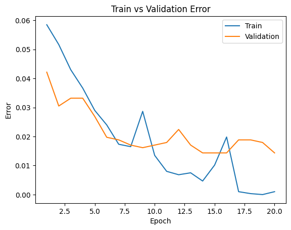

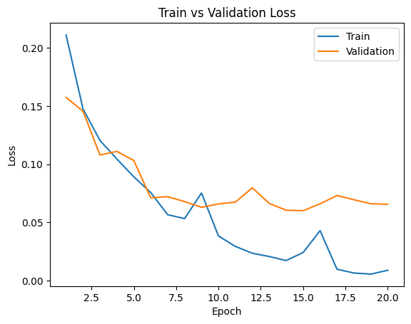

```python
vocab_size = len(stoi) # Number of unique characters including padding
model = RNN(vocab_size=vocab_size, hidden_size=50)
train(model, train_loader, val_loader, learning_rate=0.001, num_epochs = 20)
model_path = get_model_name("rnn", 32, 0.001, 19)
plot_training_curve(model_path)
```

### Part (c) [4 pt]

Choose at least 4 hyperparameters to tune. Explain how you tuned the hyperparameters. You don't need to include your training curve for every model you trained. Instead, explain what hyperparemters you tuned, what the best validation accuracy was, and the reasoning behind the hyperparameter decisions you made.

For this assignment, you should tune more than just your learning rate and epoch. Choose at least 2 hyperparameters that are unrelated to the optimizer.

```python
# Change the learning rate from 0.001 to 0.0001
model = RNN(vocab_size=vocab_size, hidden_size=50)
train(model, train_loader, val_loader, learning_rate=0.0001, num_epochs = 20)
model_path = get_model_name("rnn", 32, 0.0001, 19)
```

```
Epoch 1: Train err: 0.4828390536487837, Train loss: 0.675193688970931 | Validation err: 0.8717488789237668, Validation loss: 0.7054981878825597
Epoch 2: Train err: 0.17544151949350217, Train loss: 0.5193660520809762 | Validation err: 0.3022421524663677, Validation loss: 0.659533737386976
Epoch 3: Train err: 0.06781072975674775, Train loss: 0.34113609442051424 | Validation err: 0.10044843049327354, Validation loss: 0.5239080599376134
Epoch 4: Train err: 0.06331222925691436, Train loss: 0.28409728336524454 | Validation err: 0.09417040358744394, Validation loss: 0.32736310277666364
Epoch 5: Train err: 0.06097967344218594, Train loss: 0.2417630164467908 | Validation err: 0.08161434977578476, Validation loss: 0.2901127828019006
Epoch 6: Train err: 0.06047984005331556, Train loss: 0.22281791222222308 | Validation err: 0.06098654708520179, Validation loss: 0.22370002291032245
Epoch 7: Train err: 0.05731422859046984, Train loss: 0.21354623943408754 | Validation err: 0.06367713004484304, Validation loss: 0.21177405544689723
Epoch 8: Train err: 0.0546484505164945, Train loss: 0.19952405549268773 | Validation err: 0.05560538116591928, Validation loss: 0.1969844896878515
Epoch 9: Train err: 0.05581472842385871, Train loss: 0.19329370792083284 | Validation err: 0.05739910313901345, Validation loss: 0.20160828786236898
Epoch 10: Train err: 0.18193935354881707, Train loss: 0.4727551637494818 | Validation err: 0.34618834080717487, Validation loss: 0.8516853102615901
Epoch 11: Train err: 0.04981672775741419, Train loss: 0.1772028323104407 | Validation err: 0.05650224215246637, Validation loss: 0.1758329357419695
Epoch 12: Train err: 0.07314228590469843, Train loss: 0.21275164531742005 | Validation err: 0.12645739910313902, Validation loss: 0.27224375158548353
Epoch 13: Train err: 0.06781072975674775, Train loss: 0.23258459377796092 | Validation err: 0.04753363228699552, Validation loss: 0.15372943271483694
Epoch 14: Train err: 0.04965011662779074, Train loss: 0.17518353824840582 | Validation err: 0.06098654708520179, Validation loss: 0.20339352999414717
Epoch 15: Train err: 0.04781739420193269, Train loss: 0.17064190772857438 | Validation err: 0.06098654708520179, Validation loss: 0.19457247321094787
Epoch 16: Train err: 0.07230923025658113, Train loss: 0.21007225317682357 | Validation err: 0.11569506726457399, Validation loss: 0.3059857689908573
Epoch 17: Train err: 0.04748417194268577, Train loss: 0.16425330112589168 | Validation err: 0.059192825112107626, Validation loss: 0.18075744520340647
Epoch 18: Train err: 0.046817727424191935, Train loss: 0.16007670229102702 | Validation err: 0.05291479820627803, Validation loss: 0.16619064435362815
Epoch 19: Train err: 0.04648450516494502, Train loss: 0.15770256634246796 | Validation err: 0.06457399103139014, Validation loss: 0.19337923271315438
Epoch 20: Train err: 0.044151949350216595, Train loss: 0.15250504569725154 | Validation err: 0.05201793721973094, Validation loss: 0.1886267265038831
```

```
Epoch 1: Train err: 0.05881372875708097, Train loss: 0.1897182923127362 | Validation err: 0.02780269058295964, Validation loss: 0.20249391900641578
Epoch 2: Train err: 0.22892369210263244, Train loss: 0.46228088073908014 | Validation err: 0.4026905829596413, Validation loss: 0.6238307799611773
Epoch 3: Train err: 0.0461512829056981, Train loss: 0.2542623535115668 | Validation err: 0.04125560538116592, Validation loss: 0.2667825605188097
Epoch 4: Train err: 0.040986337887370876, Train loss: 0.11674673058726687 | Validation err: 0.04035874439461883, Validation loss: 0.11363707967102528
Epoch 5: Train err: 0.04215261579473509, Train loss: 0.11887740103052334 | Validation err: 0.017937219730941704, Validation loss: 0.06558032911270857
Epoch 6: Train err: 0.028157280906364546, Train loss: 0.08418516780031805 | Validation err: 0.023318385650224215, Validation loss: 0.09445922710001468
Epoch 7: Train err: 0.021159613462179275, Train loss: 0.06465287674020262 | Validation err: 0.017040358744394617, Validation loss: 0.06680503945265498
Epoch 8: Train err: 0.016994335221592802, Train loss: 0.05420391842663447 | Validation err: 0.019730941704035873, Validation loss: 0.0704435489273497
Epoch 9: Train err: 0.014161946017994002, Train loss: 0.046349190720456075 | Validation err: 0.017040358744394617, Validation loss: 0.06058741451374122
Epoch 10: Train err: 0.009496834388537155, Train loss: 0.031692208271434014 | Validation err: 0.017040358744394617, Validation loss: 0.05695395349924053
Epoch 11: Train err: 0.007830723092302566, Train loss: 0.023142789844720763 | Validation err: 0.013452914798206279, Validation loss: 0.051866196122552666
Epoch 12: Train err: 0.007497500833055648, Train loss: 0.020392246995780103 | Validation err: 0.017937219730941704, Validation loss: 0.057397049758583306
Epoch 13: Train err: 0.004498500499833389, Train loss: 0.01654535758326405 | Validation err: 0.016143497757847534, Validation loss: 0.06033723301786397
Epoch 14: Train err: 0.002165944685104965, Train loss: 0.010049867614338353 | Validation err: 0.017040358744394617, Validation loss: 0.06844638083795351
Epoch 15: Train err: 0.0013328890369876708, Train loss: 0.006885551383713894 | Validation err: 0.013452914798206279, Validation loss: 0.06255327238551607
Epoch 16: Train err: 0.0004998333888703765, Train loss: 0.004331300813956137 | Validation err: 0.017937219730941704, Validation loss: 0.07271386565574045
Epoch 17: Train err: 0.01016327890703099, Train loss: 0.029818850522675116 | Validation err: 0.016143497757847534, Validation loss: 0.07837886382226965
Epoch 18: Train err: 0.0004998333888703765, Train loss: 0.00631927504288429 | Validation err: 0.011659192825112108, Validation loss: 0.059847538191492536
Epoch 19: Train err: 0.0, Train loss: 0.0031285273699006907 | Validation err: 0.015246636771300448, Validation loss: 0.06325867243410488
Epoch 20: Train err: 0.0008330556481172943, Train loss: 0.005122721654883439 | Validation err: 0.012556053811659192, Validation loss: 0.07612088146062368
Epoch 21: Train err: 0.0, Train loss: 0.0010730741663056952 | Validation err: 0.017937219730941704, Validation loss: 0.0749074631478704
Epoch 22: Train err: 0.002999000333222259, Train loss: 0.010005621364704913 | Validation err: 0.010762331838565023, Validation loss: 0.06943680559218463
Epoch 23: Train err: 0.0, Train loss: 0.002110458290073748 | Validation err: 0.013452914798206279, Validation loss: 0.0681659931757687
Epoch 24: Train err: 0.0, Train loss: 0.001045786295551497 | Validation err: 0.015246636771300448, Validation loss: 0.07294145424509355
Epoch 25: Train err: 0.026324558480506497, Train loss: 0.0706679339160241 | Validation err: 0.06816143497757847, Validation loss: 0.22774341510874885
Epoch 26: Train err: 0.0, Train loss: 0.002098573403329399 | Validation err: 0.014349775784753363, Validation loss: 0.0673919200090625
Epoch 27: Train err: 0.0, Train loss: 0.0008239855272396643 | Validation err: 0.014349775784753363, Validation loss: 0.07497943783528171
Epoch 28: Train err: 0.0, Train loss: 0.0005176473071785833 | Validation err: 0.014349775784753363, Validation loss: 0.07642146633235306
Epoch 29: Train err: 0.0, Train loss: 0.0003207351033547348 | Validation err: 0.013452914798206279, Validation loss: 0.0773389274290821
Epoch 30: Train err: 0.0, Train loss: 0.00024610514450846784 | Validation err: 0.014349775784753363, Validation loss: 0.07923288411069994
```

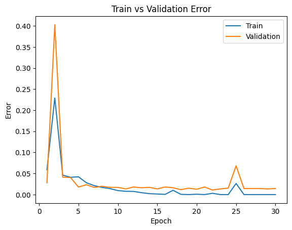

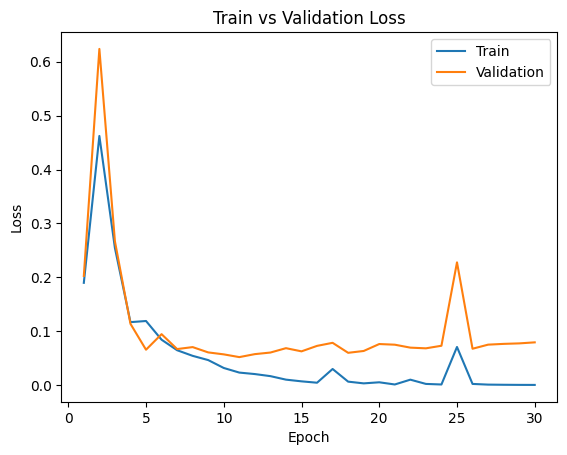

```python
# Increase the number of hidden units from 50 to 128
model = RNN(vocab_size=vocab_size, hidden_size=128)
train(model, train_loader, val_loader, learning_rate=0.001, num_epochs = 30)
model_path = get_model_name("rnn", 32, 0.001, 29)
plot_training_curve(model_path)
```

```
Epoch 1: Train err: 0.08697100966344552, Train loss: 0.27436868497665895 | Validation err: 0.026905829596412557, Validation loss: 0.3105558554331462
Epoch 2: Train err: 0.04965011662779074, Train loss: 0.17944767330079636 | Validation err: 0.04484304932735426, Validation loss: 0.21269781721962822
Epoch 3: Train err: 0.04448517160946351, Train loss: 0.15954808979988733 | Validation err: 0.03587443946188341, Validation loss: 0.1477466393262148
Epoch 4: Train err: 0.040986337887370876, Train loss: 0.1662828137582921 | Validation err: 0.04035874439461883, Validation loss: 0.19821975380182266
Epoch 5: Train err: 0.04081972675774742, Train loss: 0.12042053016100793 | Validation err: 0.028699551569506727, Validation loss: 0.11812766372329658
Epoch 6: Train err: 0.03448850383205598, Train loss: 0.10577381210044977 | Validation err: 0.023318385650224215, Validation loss: 0.09725322636465232
Epoch 7: Train err: 0.028490503165611462, Train loss: 0.09779959851677747 | Validation err: 0.02062780269058296, Validation loss: 0.08497101844598849
Epoch 8: Train err: 0.0291569476841053, Train loss: 0.08657514183048873 | Validation err: 0.02242152466367713, Validation loss: 0.09337507374584675
Epoch 9: Train err: 0.028490503165611462, Train loss: 0.07713490942532712 | Validation err: 0.023318385650224215, Validation loss: 0.09626926285111242
Epoch 10: Train err: 0.02015994668443852, Train loss: 0.06774845999725004 | Validation err: 0.0242152466367713, Validation loss: 0.08234327762491173
Epoch 11: Train err: 0.016827724091969344, Train loss: 0.05813531740073194 | Validation err: 0.02780269058295964, Validation loss: 0.09189388590554397
Epoch 12: Train err: 0.015161612795734756, Train loss: 0.04942333554611244 | Validation err: 0.026905829596412557, Validation loss: 0.08580585796799925
Epoch 13: Train err: 0.017994001999333556, Train loss: 0.05658800741459461 | Validation err: 0.019730941704035873, Validation loss: 0.06673245921006633
Epoch 14: Train err: 0.016661112962345886, Train loss: 0.05010826947127885 | Validation err: 0.021524663677130046, Validation loss: 0.06752999959927466
Epoch 15: Train err: 0.008330556481172943, Train loss: 0.036361699037134966 | Validation err: 0.02780269058295964, Validation loss: 0.09026990210016568
Epoch 16: Train err: 0.00583138953682106, Train loss: 0.02915225660012282 | Validation err: 0.025112107623318385, Validation loss: 0.07806950372954209
Epoch 17: Train err: 0.010996334555148283, Train loss: 0.03103788474951177 | Validation err: 0.02242152466367713, Validation loss: 0.07686876703519374
Epoch 18: Train err: 0.007664111962679107, Train loss: 0.02519608042549659 | Validation err: 0.021524663677130046, Validation loss: 0.07886107529823978
Epoch 19: Train err: 0.009496834388537155, Train loss: 0.02456842647479015 | Validation err: 0.019730941704035873, Validation loss: 0.07624098050615026
Epoch 20: Train err: 0.004998333888703766, Train loss: 0.01789218061752221 | Validation err: 0.02062780269058296, Validation loss: 0.08042505613735153
Epoch 21: Train err: 0.01149616794401866, Train loss: 0.025938796751359676 | Validation err: 0.01883408071748879, Validation loss: 0.07473048971345027
Epoch 22: Train err: 0.010329890036654448, Train loss: 0.022391485835504817 | Validation err: 0.017937219730941704, Validation loss: 0.07558385539515358
Epoch 23: Train err: 0.0023325558147284237, Train loss: 0.022025778364548658 | Validation err: 0.02062780269058296, Validation loss: 0.0725553773291823
Epoch 24: Train err: 0.001999333555481506, Train loss: 0.012511564178412106 | Validation err: 0.02242152466367713, Validation loss: 0.08137064713001665
Epoch 25: Train err: 0.007664111962679107, Train loss: 0.023726502377688488 | Validation err: 0.02780269058295964, Validation loss: 0.10175777309470707
Epoch 26: Train err: 0.007997334221926024, Train loss: 0.025316862790706628 | Validation err: 0.017040358744394617, Validation loss: 0.07223780496537478
Epoch 27: Train err: 0.0014995001666111296, Train loss: 0.010198968986514956 | Validation err: 0.01883408071748879, Validation loss: 0.07272007782658976
Epoch 28: Train err: 0.002499166944351883, Train loss: 0.012760872607109473 | Validation err: 0.021524663677130046, Validation loss: 0.08736353419953957
Epoch 29: Train err: 0.000999666777740753, Train loss: 0.008063217330268248 | Validation err: 0.01883408071748879, Validation loss: 0.07637580237092657
Epoch 30: Train err: 0.000999666777740753, Train loss: 0.006763975548389507 | Validation err: 0.01883408071748879, Validation loss: 0.07725087575899023
```

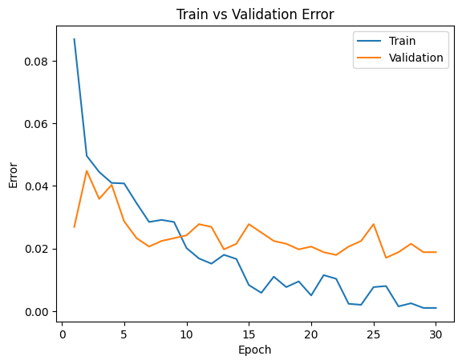

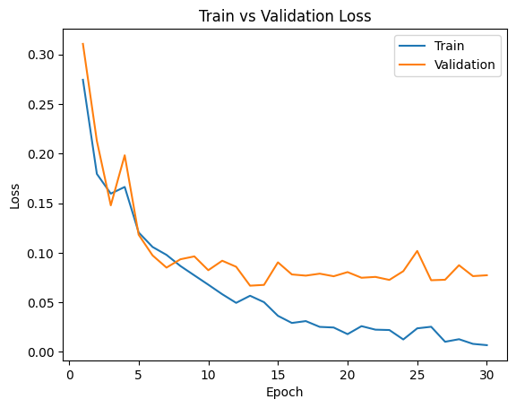

```python
# Change batch size from 32 to 64
train_loader = DataLoader(dataset=MyDataset(train_x, train_y), batch_size= 64, shuffle=True, collate_fn=collate_sequences)
val_loader = DataLoader(dataset=MyDataset(val_x, val_y), batch_size=64, shuffle=False, collate_fn=collate_sequences)

model = RNN(vocab_size=vocab_size, hidden_size=50)
train(model, train_loader, val_loader, learning_rate=0.001, num_epochs = 30)
model_path = get_model_name("rnn", 64, 0.001, 29)
plot_training_curve(model_path)
```

```
Epoch 1: Train err: 0.05681439520159947, Train loss: 0.17783352581070774 | Validation err: 0.03587443946188341, Validation loss: 0.16576905708227838
Epoch 2: Train err: 0.05198267244251916, Train loss: 0.14231975034790786 | Validation err: 0.02062780269058296, Validation loss: 0.10296957806817122
Epoch 3: Train err: 0.04448517160946351, Train loss: 0.1238724325109828 | Validation err: 0.02600896860986547, Validation loss: 0.1098071711403983
Epoch 4: Train err: 0.03898700433188937, Train loss: 0.10822495499110603 | Validation err: 0.019730941704035873, Validation loss: 0.09742181737508093
Epoch 5: Train err: 0.02865711429523492, Train loss: 0.0852884315994588 | Validation err: 0.02242152466367713, Validation loss: 0.09229612020509584
Epoch 6: Train err: 0.02465844718427191, Train loss: 0.07843983841148462 | Validation err: 0.02242152466367713, Validation loss: 0.09264927117952279
Epoch 7: Train err: 0.02149283572142619, Train loss: 0.06333687565502454 | Validation err: 0.01883408071748879, Validation loss: 0.06487149566944156
Epoch 8: Train err: 0.019660113295568143, Train loss: 0.05804240873994979 | Validation err: 0.019730941704035873, Validation loss: 0.07373255121388606
Epoch 9: Train err: 0.017494168610463177, Train loss: 0.053548472091317814 | Validation err: 0.021524663677130046, Validation loss: 0.08861558772623539
Epoch 10: Train err: 0.014161946017994002, Train loss: 0.041553873578680955 | Validation err: 0.017040358744394617, Validation loss: 0.062397164558725696
Epoch 11: Train err: 0.019326891036321226, Train loss: 0.05150467010853971 | Validation err: 0.016143497757847534, Validation loss: 0.05777424383642418
Epoch 12: Train err: 0.010496501166277908, Train loss: 0.03436377668688866 | Validation err: 0.019730941704035873, Validation loss: 0.07344762589782476
Epoch 13: Train err: 0.011829390203265578, Train loss: 0.03265001260560313 | Validation err: 0.015246636771300448, Validation loss: 0.05280207447441561
Epoch 14: Train err: 0.009996667777407531, Train loss: 0.02660054134445245 | Validation err: 0.014349775784753363, Validation loss: 0.056505761880959786
Epoch 15: Train err: 0.008163945351549483, Train loss: 0.021630969939461137 | Validation err: 0.014349775784753363, Validation loss: 0.0540509648221944
Epoch 16: Train err: 0.006331222925691436, Train loss: 0.018082140152902403 | Validation err: 0.013452914798206279, Validation loss: 0.056628612289205196
Epoch 17: Train err: 0.00583138953682106, Train loss: 0.015309452902193757 | Validation err: 0.017040358744394617, Validation loss: 0.06369524315066104
Epoch 18: Train err: 0.005498167277574142, Train loss: 0.017517459910719634 | Validation err: 0.017040358744394617, Validation loss: 0.06441128919832409
Epoch 19: Train err: 0.011829390203265578, Train loss: 0.03462782944521639 | Validation err: 0.030493273542600896, Validation loss: 0.0998664764820465
Epoch 20: Train err: 0.005998000666444518, Train loss: 0.01408456373982072 | Validation err: 0.015246636771300448, Validation loss: 0.06301937658738876
Epoch 21: Train err: 0.0038320559813395535, Train loss: 0.0157108106668989 | Validation err: 0.02242152466367713, Validation loss: 0.08176218621499304
Epoch 22: Train err: 0.0016661112962345886, Train loss: 0.009764235479722513 | Validation err: 0.017040358744394617, Validation loss: 0.06397501588965367
Epoch 23: Train err: 0.0011662779073642118, Train loss: 0.0069755985066567135 | Validation err: 0.017040358744394617, Validation loss: 0.06803640152460762
Epoch 24: Train err: 0.009996667777407531, Train loss: 0.027574247532608384 | Validation err: 0.02780269058295964, Validation loss: 0.1156896901716079
Epoch 25: Train err: 0.0014995001666111296, Train loss: 0.007280237301722778 | Validation err: 0.015246636771300448, Validation loss: 0.06003004694523822
Epoch 26: Train err: 0.0011662779073642118, Train loss: 0.006187913320513387 | Validation err: 0.017937219730941704, Validation loss: 0.07380503706683937
Epoch 27: Train err: 0.0004998333888703765, Train loss: 0.004439238453724488 | Validation err: 0.016143497757847534, Validation loss: 0.06839507451222744
Epoch 28: Train err: 0.0008330556481172943, Train loss: 0.004526081186261937 | Validation err: 0.011659192825112108, Validation loss: 0.06340319877324094
Epoch 29: Train err: 0.00583138953682106, Train loss: 0.020402961557804102 | Validation err: 0.029596412556053813, Validation loss: 0.11539490852238876
Epoch 30: Train err: 0.0004998333888703765, Train loss: 0.00530117405109427 | Validation err: 0.016143497757847534, Validation loss: 0.06683644853931453
```

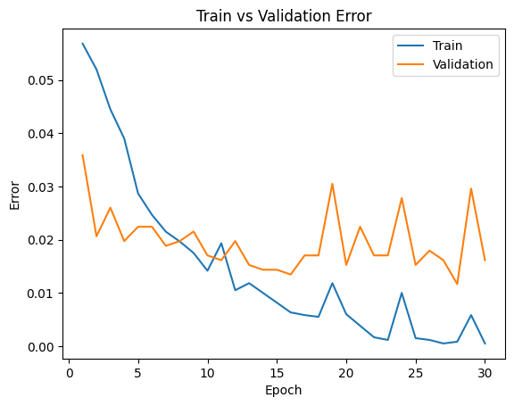

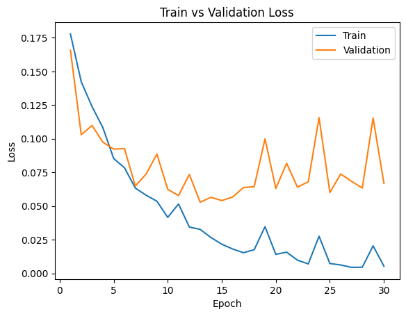

```python
# Switch from max pooling to max + average pooling in the RNN model
class RNN(nn.Module):
    def __init__(self, vocab_size, hidden_size, n_layers=1):
        super(RNN, self).__init__()
        self.ident = torch.eye(vocab_size)
        self.rnn = nn.GRU(vocab_size, hidden_size, n_layers, batch_first=True)

        self.classifier = nn.Linear(hidden_size * 2, 2) # hidden_size * 2 since concatenating two vectors

    def forward(self, x):
        inp_x = self.ident[x]
        output, _ = self.rnn(inp_x)

        out = torch.cat([torch.max(output, dim=1)[0], torch.mean(output, dim=1)], dim=1) # Concatenate max pooling and average pooling
        out = self.classifier(out)
        return out

train_loader = DataLoader(dataset=MyDataset(train_x, train_y), batch_size= 32, shuffle=True, collate_fn=collate_sequences)
val_loader = DataLoader(dataset=MyDataset(val_x, val_y), batch_size=32, shuffle=False, collate_fn=collate_sequences)

model = RNN(vocab_size=vocab_size, hidden_size=50)
train(model, train_loader, val_loader, learning_rate=0.001, num_epochs = 30)
model_path = get_model_name("rnn", 32, 0.001, 29)
plot_training_curve(model_path)
```

Final Model Parameters:

1. Learning rate: 0.001
2. Batch size: 32
3. Number of hidden units: 128
4. Pooling strategy: Max pooling

```
Epoch 1: Train err: 0.05881372875708097, Train loss: 0.19259408635503433 | Validation err: 0.026905829596412557, Validation loss: 0.19750876554421015
Epoch 2: Train err: 0.07597467510829724, Train loss: 0.2650243876145241 | Validation err: 0.11569506726457399, Validation loss: 0.2901255020073482
Epoch 3: Train err: 0.044318560479840056, Train loss: 0.13304822110234105 | Validation err: 0.05291479820627803, Validation loss: 0.14033029611621584
Epoch 4: Train err: 0.036654448517160945, Train loss: 0.10856746437345097 | Validation err: 0.025112107623318385, Validation loss: 0.10743939376303129
Epoch 5: Train err: 0.02732422525824725, Train loss: 0.07988675011004856 | Validation err: 0.02242152466367713, Validation loss: 0.0911237856639283
Epoch 6: Train err: 0.016994335221592802, Train loss: 0.05623343056365055 | Validation err: 0.021524663677130046, Validation loss: 0.07132789359561034
Epoch 7: Train err: 0.013328890369876709, Train loss: 0.03988589303681944 | Validation err: 0.02062780269058296, Validation loss: 0.051479021819042306
Epoch 8: Train err: 0.016161279573475507, Train loss: 0.04073029482103092 | Validation err: 0.012556053811659192, Validation loss: 0.045622970589569635
Epoch 9: Train err: 0.005664778407197601, Train loss: 0.022480250828517997 | Validation err: 0.017040358744394617, Validation loss: 0.05150814029454653
Epoch 10: Train err: 0.0041652782405864714, Train loss: 0.019334538456144187 | Validation err: 0.01883408071748879, Validation loss: 0.05502099668207978
Epoch 11: Train err: 0.00433188937020993, Train loss: 0.014370733868340625 | Validation err: 0.016143497757847534, Validation loss: 0.04717208620027772
Epoch 12: Train err: 0.0013328890369876708, Train loss: 0.008344538810791726 | Validation err: 0.01883408071748879, Validation loss: 0.056098586793190665
Epoch 13: Train err: 0.0004998333888703765, Train loss: 0.006024053546617382 | Validation err: 0.016143497757847534, Validation loss: 0.05633824389328116
Epoch 14: Train err: 0.0008330556481172943, Train loss: 0.0069835055777381985 | Validation err: 0.017040358744394617, Validation loss: 0.05371960022686315
Epoch 15: Train err: 0.00016661112962345885, Train loss: 0.002079859490975728 | Validation err: 0.017040358744394617, Validation loss: 0.06028040964405851
Epoch 16: Train err: 0.0, Train loss: 0.001899137590411788 | Validation err: 0.017937219730941704, Validation loss: 0.06490129128173326
Epoch 17: Train err: 0.0, Train loss: 0.0012083532086607908 | Validation err: 0.017040358744394617, Validation loss: 0.07241466453249035
Epoch 18: Train err: 0.0, Train loss: 0.0010241192251650066 | Validation err: 0.016143497757847534, Validation loss: 0.07470595621634857
Epoch 19: Train err: 0.0, Train loss: 0.000483711091371159 | Validation err: 0.017937219730941704, Validation loss: 0.07524751953148683
Epoch 20: Train err: 0.0, Train loss: 0.0004321318591927535 | Validation err: 0.017937219730941704, Validation loss: 0.07038515231709296
Epoch 21: Train err: 0.0, Train loss: 0.0002838952346269736 | Validation err: 0.017040358744394617, Validation loss: 0.08115781591477571
Epoch 22: Train err: 0.0, Train loss: 0.000206640383726637 | Validation err: 0.017040358744394617, Validation loss: 0.08717200185523584
Epoch 23: Train err: 0.0, Train loss: 0.0002060884929709031 | Validation err: 0.017937219730941704, Validation loss: 0.08850762675564121
Epoch 24: Train err: 0.0, Train loss: 0.00013920219578509167 | Validation err: 0.017937219730941704, Validation loss: 0.09312023708579155
Epoch 25: Train err: 0.0, Train loss: 0.00010331132531315776 | Validation err: 0.017937219730941704, Validation loss: 0.09820875892582989
Epoch 26: Train err: 0.0, Train loss: 8.041185570047983e-05 | Validation err: 0.017937219730941704, Validation loss: 0.10117686504987172
Epoch 27: Train err: 0.0, Train loss: 6.507221868356825e-05 | Validation err: 0.017937219730941704, Validation loss: 0.10719786263133366
Epoch 28: Train err: 0.006997667444185272, Train loss: 0.02114009977618054 | Validation err: 0.017040358744394617, Validation loss: 0.047666557159807
Epoch 29: Train err: 0.0003332222592469177, Train loss: 0.003769547938142576 | Validation err: 0.016143497757847534, Validation loss: 0.05448454218317888
Epoch 30: Train err: 0.0, Train loss: 0.0013735769994224377 | Validation err: 0.015246636771300448, Validation loss: 0.0623840932152234
```

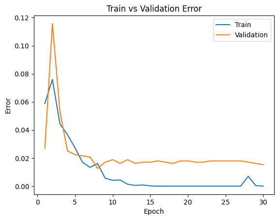

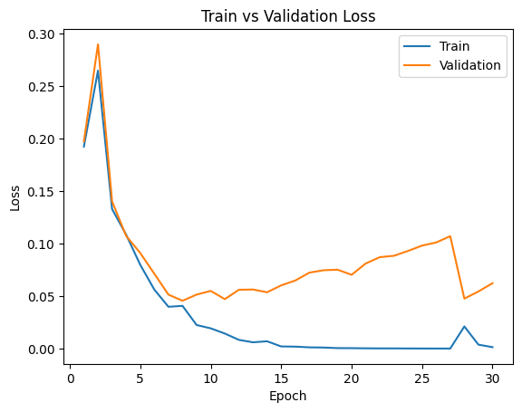

```python
class bestRNN(nn.Module):
  def __init__(self, vocab_size, hidden_size, n_layers=1):
      super(bestRNN, self).__init__()

      self.ident = torch.eye(vocab_size)
      self.rnn = nn.GRU(vocab_size, hidden_size, n_layers, batch_first=True)
      self.classifier = nn.Linear(hidden_size, 2)

  def forward(self, x):
      inp_x = self.ident[x]
      output, _ = self.rnn(inp_x)

      out = torch.max(output, dim=1)[0]

      out = self.classifier(out)
      return out

best_model = bestRNN(vocab_size=vocab_size, hidden_size=128)
train(best_model, train_loader, val_loader, learning_rate=0.001, num_epochs = 30)
bestmodel_path = get_model_name("rnn", 32, 0.001, 29)
plot_training_curve(bestmodel_path)
```

### Part (d) [2 pt]

Before we deploy a machine learning model, we usually want to have a better understanding of how our model performs beyond its validation accuracy. An important metric to track is *how well our model performs in certain subsets of the data*.

In particular, what is the model's error rate amongst data with negative labels? This is called the **false positive rate**.

What about the model's error rate amongst data with positive labels? This is called the **false negative rate**.

Report your final model's false positive and false negative rate across the validation set.

```python
def get_fp_fn_rates(model, data_loader):
    fp = 0 # False positives: predicted spam (1) but the actual label was ham (0)
    tn = 0 # True negatives: predicted ham (0) and the actual label was ham (0)
    fn = 0 # False negatives: predicted ham (0) but the actual label was spam (1)
    tp = 0 # True positives: predicted spam (1) and the actual label was spam (1)

    with torch.no_grad():
        for sequences, labels in data_loader:
            outputs = model(sequences)
            preds = outputs.max(1, keepdim=True)[1].squeeze() # get predicted class
            labels = labels.long()

            fp += ((preds == 1) & (labels == 0)).sum().item()
            tn += ((preds == 0) & (labels == 0)).sum().item()

            fn += ((preds == 0) & (labels == 1)).sum().item()
            tp += ((preds == 1) & (labels == 1)).sum().item()

    fpr = fp / (fp + tn) if (fp + tn) > 0 else 0
    fnr = fn / (fn + tp) if (fn + tp) > 0 else 0

    print(f"False Positive Rate: {fpr:.4f} -> {fp} false positives for {fp + tn} actual hams")
    print(f"False Negative Rate: {fnr:.4f} -> {fn} false negatives for {fn + tp} actual spams")

get_fp_fn_rates(best_model, val_loader)
```

```
False Positive Rate: 0.0082 -> 8 false positives for 972 actual hams
False Negative Rate: 0.0629 -> 9 false negatives for 143 actual spams
```

### Part (e) [2 pt]

The impact of a false positive vs a false negative can be drastically different. If our spam detection algorithm was deployed on your phone, what is the impact of a false positive on the phone's user? What is the impact of a false negative?

A false negative means that a spam message was able to get through to the user, which would just be annoying at worst. However, a false positive would mean that a real message was labeled as spam, which could prevent the user from ever seeing that message. For example, if the message is urgent and requires user response, a false positive would have a huge impact.

## Part 4. Evaluation [11 pt]

### Part (a) [1 pt]

Report the final test accuracy of your model.

```python
criterion = nn.CrossEntropyLoss()
test_err, test_loss = evaluate(best_model, test_loader, criterion)
test_accuracy = 1.0 - test_err

print(f"Final Test Accuracy: {test_accuracy * 100:.2f}%")
print(f"Final Test Loss: {test_loss:.4f}")
```

```
Final Test Accuracy: 98.12%
Final Test Loss: 0.0720
```

### Part (b) [3 pt]

Report the false positive rate and false negative rate of your model across the test set.

```python
get_fp_fn_rates(best_model, test_loader)
```

```
False Positive Rate: 0.0105 -> 10 false positives for 954 actual hams
False Negative Rate: 0.0683 -> 11 false negatives for 161 actual spams
```

### Part (c) [3 pt]

What is your model's prediction of the **probability** that the SMS message "machine learning is sooo cool!" is spam?

Hint: To begin, use `stoi` to look up the index of each character in the vocabulary.

```python
msg = "machine learning is sooo cool!"
indices = [stoi[char] for char in msg] # Convert char to indices using vocab mapping
sequence_tensor = torch.tensor(indices).unsqueeze(0) # convert to pytorch tensor

logits = best_model(sequence_tensor)
probabilities = F.softmax(logits, dim=1)
spam_prob = probabilities[0][1].item()

print(f"Spam probability of message '{msg}': {spam_prob * 100:.2f}%")
```

```
Spam probability of message 'machine learning is sooo cool!': 0.11%
```

### Part (d) [4 pt]

Do you think detecting spam is an easy or difficult task?

Since machine learning models are expensive to train and deploy, it is very important to compare our models against baseline models: a simple model that is easy to build and inexpensive to run that we can compare our recurrent neural network model against.

Explain how you might build a simple baseline model. This baseline model can be a simple neural network (with very few weights), a hand-written algorithm, or any other strategy that is easy to build and test.

**Do not actually build a baseline model. Instead, provide instructions on how to build it.**

Detecting spam is a simple task. One way to do it is to use a TF-IDF Vectorizer, which will count how often specific keywords appear in a message. This is the perfect method for detecting spam, since many spam messages rely on eye catching trigger words instead of sentence context/structure. Not only is this effective for detecting spam, it is simple to implement and test against our RNN model.